# Práctica Visualización de Datos

Mireia Perpiñá Valdés

2025-01-09

## Carga y Limpieza de dataset

Empezamos cargando el dataset:

```r
library(readr)
data <- read_csv("C:/Users/Mireia/Downloads/Student_Depression_Dataset.csv", show_col_types = FALSE)
```

Como comentamos en la primera parte de la práctica, todos nuestros datos pertenecen a estudiantes. Por lo tanto, no son necesarias las variables *Profession, Work Pressure, Job Satisfaction*. Las quitamos:

```r
library(dplyr)
```

```r
data <- data[, c("id","Gender", "Age", "City", "Academic Pressure", "CGPA", "Study Satisfaction", "Sleep Duration", "Dietary Habits", "Degree", "Have you ever had suicidal thoughts ?", "Work/Study Hours", "Financial Stress", "Family History of Mental Illness","Depression")]
```

Vemos un resumen de nuestros datos:

```r
summary(data)
```

```
##        id            Gender               Age            City
##  Min.   :     2   Length:27901       Min.   :18.00   Length:27901
##  1st Qu.: 35039   Class :character   1st Qu.:21.00   Class :character
##  Median : 70684   Mode  :character   Median :25.00   Mode  :character
##  Mean   : 70442                      Mean   :25.82
##  3rd Qu.:105818                      3rd Qu.:30.00
##  Max.   :140699                      Max.   :59.00
##
##  Academic Pressure      CGPA        Study Satisfaction Sleep Duration
##  Min.   :0.000     Min.   : 0.000   Min.   :0.000      Length:27901
##  1st Qu.:2.000     1st Qu.: 6.290   1st Qu.:2.000      Class :character
##  Median :3.000     Median : 7.770   Median :3.000      Mode  :character
##  Mean   :3.141     Mean   : 7.656   Mean   :2.944
##  3rd Qu.:4.000     3rd Qu.: 8.920   3rd Qu.:4.000
##  Max.   :5.000     Max.   :10.000   Max.   :5.000
##
##  Dietary Habits        Degree          Have you ever had suicidal thoughts ?
##  Length:27901       Length:27901       Length:27901
##  Class :character   Class :character   Class :character
##  Mode  :character   Mode  :character   Mode  :character
##
##
##
##
##  Work/Study Hours Financial Stress Family History of Mental Illness
##  Min.   : 0.000   Min.   :1.00     Length:27901
##  1st Qu.: 4.000   1st Qu.:2.00     Class :character
##  Median : 8.000   Median :3.00     Mode  :character
##  Mean   : 7.157   Mean   :3.14
##  3rd Qu.:10.000   3rd Qu.:4.00
##  Max.   :12.000   Max.   :5.00
##                   NA's   :3
##    Depression
##  Min.   :0.0000
##  1st Qu.:0.0000
##  Median :1.0000
##  Mean   :0.5855
##  3rd Qu.:1.0000
##  Max.   :1.0000
##
```

Observamos que solo tenemos 3 valores nulos en la variable *Financial Stress*. Como en total tenemos más de 27000 registros, los tres registros que contienen valores nulos son insignificantes, por lo tanto, los eliminamos.

```r
data <- na.omit(data, cols = "Financial Stress")
# Volvemos a resumir los datos
summary(data)
```

```
##        id            Gender               Age            City
##  Min.   :     2   Length:27898       Min.   :18.00   Length:27898
##  1st Qu.: 35041   Class :character   1st Qu.:21.00   Class :character
##  Median : 70689   Mode  :character   Median :25.00   Mode  :character
##  Mean   : 70443                      Mean   :25.82
##  3rd Qu.:105825                      3rd Qu.:30.00
##  Max.   :140699                      Max.   :59.00
##  Academic Pressure      CGPA        Study Satisfaction Sleep Duration
##  Min.   :0.000     Min.   : 0.000   Min.   :0.000      Length:27898
##  1st Qu.:2.000     1st Qu.: 6.290   1st Qu.:2.000      Class :character
##  Median :3.000     Median : 7.770   Median :3.000      Mode  :character
##  Mean   :3.141     Mean   : 7.656   Mean   :2.944
##  3rd Qu.:4.000     3rd Qu.: 8.920   3rd Qu.:4.000
##  Max.   :5.000     Max.   :10.000   Max.   :5.000
##  Dietary Habits        Degree          Have you ever had suicidal thoughts ?
##  Length:27898       Length:27898       Length:27898
##  Class :character   Class :character   Class :character
##  Mode  :character   Mode  :character   Mode  :character
##
##
##
##  Work/Study Hours Financial Stress Family History of Mental Illness
##  Min.   : 0.000   Min.   :1.00     Length:27898
##  1st Qu.: 4.000   1st Qu.:2.00     Class :character
##  Median : 8.000   Median :3.00     Mode  :character
##  Mean   : 7.157   Mean   :3.14
##  3rd Qu.:10.000   3rd Qu.:4.00
##  Max.   :12.000   Max.   :5.00
##    Depression
##  Min.   :0.0000
##  1st Qu.:0.0000
##  Median :1.0000
##  Mean   :0.5855
##  3rd Qu.:1.0000
##  Max.   :1.0000
```

Ya no tenemos valores nulos. Además, en los datos anteriores tampoco parece que haya valores extremos, pues hay concordancia entre los cuartiles y los valores mínimo y máximo. Lo comprobamos de todos modos. Vamos a ver gráficamente si las variables cuantitativas (AGE, CGPA y Work/Study Hours) tienen *outliers* (no tiene mucho sentido ver si las variables categóricas tienen):

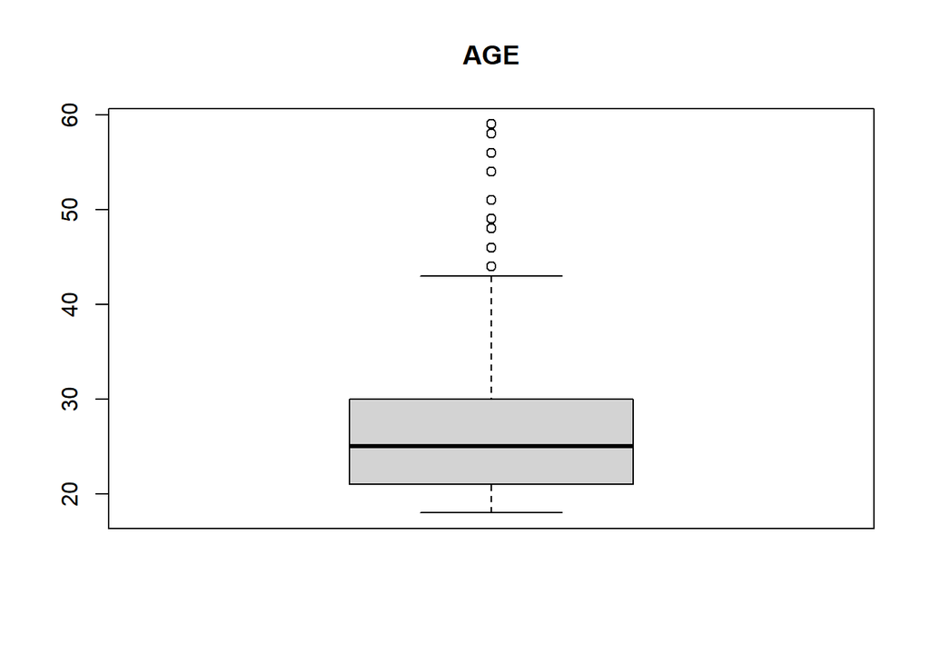

```r
# Vemos si la variable AGE tiene valores nulos
boxplot(data$Age, main = "AGE")
```

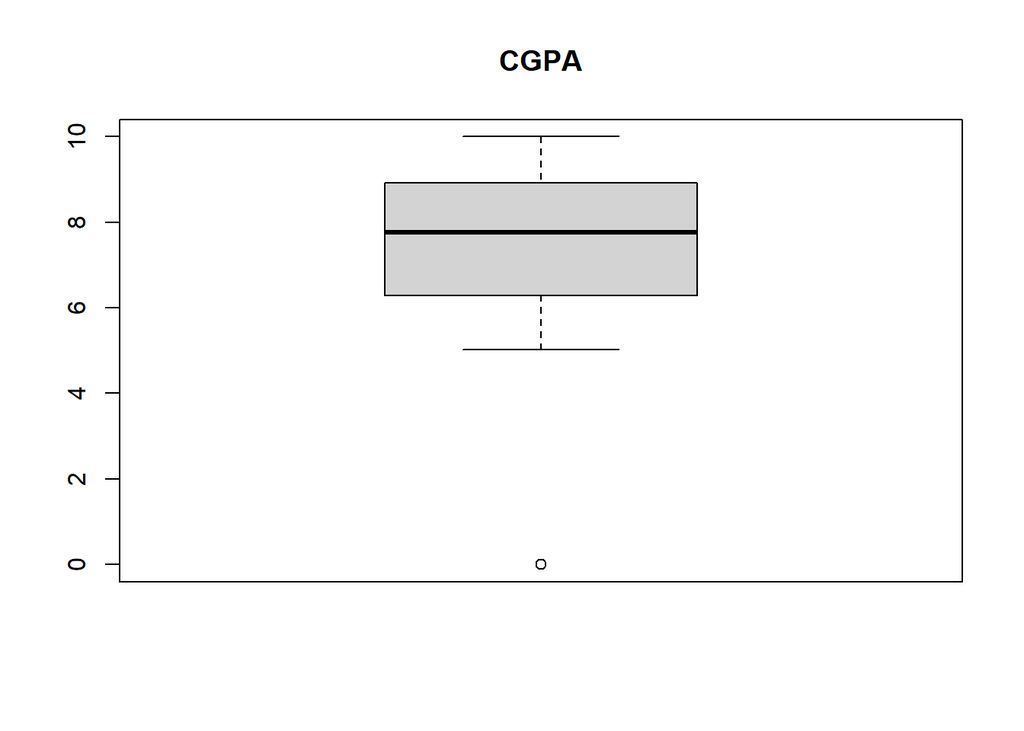

```r
# Vemos si la variable CGPA tiene valores nulos
boxplot(data$CGPA, main = "CGPA")
```

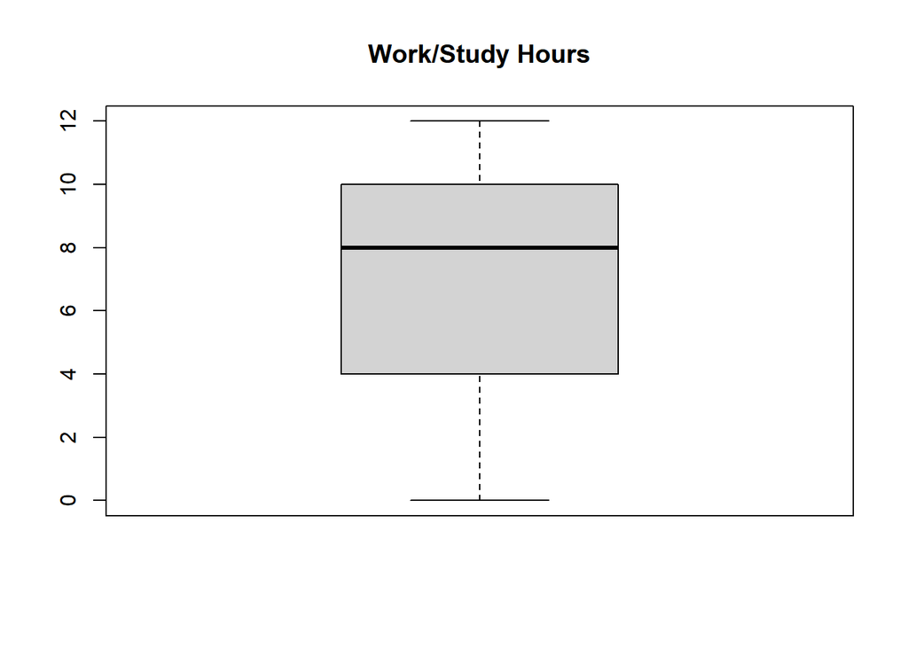

```r
# Vemos si la variable Work/Study Hours tiene valores nulos
boxplot(data$`Work/Study Hours`, main = "Work/Study Hours")
```

En la variable *Work/Study Hours* no vemos valores nulos, pero en la variable *Age* y en la variable *CGPA* sí. Como no vamos a usar la variable CGPA, no hace falta que eliminemos dicho registro. Puede ser que haya estudiantes mayores de 40 años pero como no es lo habitual y no es de no entran en nuestro caso de estudio, eliminamos dichos registros:

```r
boxplot_age <- boxplot(data$Age, plot = FALSE)
outliers <- boxplot_age$out
# Vemos de que valores se trata antes de descartarlos para asegurarnos
outliers
```

```
##  [1] 58 49 51 44 46 59 54 48 56 46 48 48
```

Como hemos dicho antes, estos casos no están dentro de nuestro caso de estudio. Además, se trata de 12 casos de más de 27000 registros. Es decir, son insignificantes, los podemos eliminar. Es más, vamos a eliminar todos aquellos mayores de 35 años para centrar nuestro estudio en los jóvenes que están en el proceso de encontrar su camino (suponiendo que a los 35 años ya se tiene una “estabilidad”)

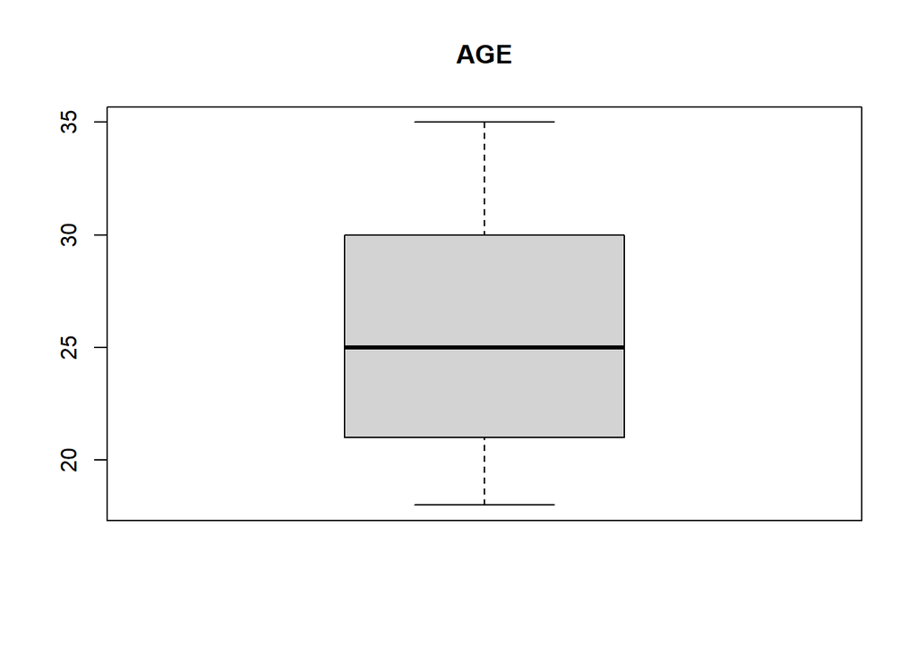

```r
data <- data[data$Age <= 35, ]
# Volvemos a dibujar el diagrama de cajas para asegurnos que se han eliminado todos los outliers
boxplot(data$Age, main = "AGE")
```

Ahora sí, ya tenemos nuestro dataset limpio de *outliers* y de valores nulos. El resto de transformaciones en las variables las haremos conforme las vayamos necesitando en los apartados siguientes.

## Preparamos diferentes subconjuntos dependiendo de la pregunta que queramos responder

Antes de empezar, vamos a cambiarle el nombre a la variable *Have you ever had suicidal thoughts?* para evitar problemas:

```r
data <- data %>% rename(Suicidal_Thoughts = "Have you ever had suicidal thoughts ?")
```

Notemos que la variable *Suicidal_Thoughts* toma los valores *Yes* y *No*. Para poder calcular totales y proporciones, necesitamos que la variable sea numérica, luego vamos a hacer una transformación. Cuando la variable tome el valor “Yes” le asignaremos un 1, cuando la variable tome el valor “No”, le asignaremos un 0. Comprobamos primero que solo toma los valores “Yes” y “No”:

```r
unique_values <- unique(data$Suicidal_Thoughts)
print(unique_values)
```

```
## [1] "Yes" "No"
```

Hacemos la transformación:

```r
data <- data %>%
  mutate(Suicidal_Thoughts = ifelse(grepl("Yes", Suicidal_Thoughts, ignore.case = TRUE), 1, 0))
summary(data$Suicidal_Thoughts)
```

```
##    Min. 1st Qu.  Median    Mean 3rd Qu.    Max.
##  0.0000  0.0000  1.0000  0.6332  1.0000  1.0000
```

Para empezar la presentación, vamos a mostrar un gráfico que nos mustre la proporción de estudiantes que tienen pensamientos suicidas en nuestra muestra a modo de introducción. Será un gráfico muy simple pues lo único que queremos es poner al espectador/a en contexto, ya aplicaremos los filtros en las siguientes visualizaciones. Preparemos entonces un conjunto de datos con esta variable:

```r
intro <- data[,c("Suicidal_Thoughts")]
# Calculamos las proporciones
intro <- intro %>%
  group_by(Suicidal_Thoughts) %>%
  summarise(
    # Calculamos las proporciones de los pensamientos suicidas por edad
    Total = n(),
    pensamientos_sui = sum(Suicidal_Thoughts, na.rm = TRUE),
    proporcion = (pensamientos_sui / Total)
  )
head(intro)
```

```
## # A tibble: 2 × 4
##   Suicidal_Thoughts Total pensamientos_sui proporcion
##               <dbl> <int>            <dbl>      <dbl>
## 1                 0 10219                0          0
## 2                 1 17640            17640          1
```

Para mejorar la legibilidad del gráfico, vamos a renombrar las categorías de la variable Suicidal_Thoughts:

```r
intro <- intro %>%
  mutate(Suicidal_Thoughts = ifelse(grepl(1, Suicidal_Thoughts, ignore.case = TRUE), "Tienen Pensamientos Suicidas","No tienen Pensamientos Suicidas"))
# Guardamos el nuevo dataset
write.csv(intro, "intro.csv", row.names = FALSE)
```

Tenemos 10.219 estudiantes sin pensamientos suicidas y 17.640 estudiantes con pensamientos suicidas. Son datos precupantes, estudiemos qué factores pueden influir:

### A qué edad se tienen más pensamientos suicidas? Estos pensamientos predominan entre hombres o mujeres?

La primera pregunta a la que queremos responder es **A qué edad se tienen más pensamientos suicidas?**. Para responder a esta pregunta vamos a necesitar las variables *Age* y *Have you ever had suicidal thoughts?*, además de la variable *Gender* para que nos permita filtrar por género. Para simplificar la carga de los datos en *Flourish Studio*, vamos a crear un csv con solo estas variables.

Ahora nos quedamos con las variables que queremos:

```r
data_edad <- data[,c("Age", "Gender", "Suicidal_Thoughts")]
```

Antes de exportar el csv, nos falta calcular las proporciones para que Flourish Studio nos pueda hacer un gráfico de barras correctamente:

```r
data_edad <- data_edad %>%
  group_by(Age,Gender) %>%
  summarise(
    # Calculamos las proporciones de los pensamientos suicidas por edad
    Total = n(),
    pensamientos_sui = sum(Suicidal_Thoughts, na.rm = TRUE),
    proporcion = (pensamientos_sui / Total)
  )
```

[output not shown]

Visualizamos las primeras filas del dataset para ver que sea correcto:

```r
head(data_edad)
```

```
## # A tibble: 6 × 5
## # Groups:   Age [3]
##     Age Gender Total pensamientos_sui proporcion
##   <dbl> <chr>  <int>            <dbl>      <dbl>
## 1    18 Female   680              498      0.732
## 2    18 Male     907              620      0.684
## 3    19 Female   709              490      0.691
## 4    19 Male     851              602      0.707
## 5    20 Female  1078              770      0.714
## 6    20 Male    1158              780      0.674
```

```r
# Creamos el nuevo csv
write.csv(data_edad, "data_edad_genero_bi.csv", row.names = FALSE)
```

### Qué situación les puede llevar a tener estos pensamientos?

Vamos a continuar estudiando los factores que pueden llevar a un estudiante a tener pensamientos suicidas. En particular, vamos a estudiar los factores: presión académica, depresión, y los hábitos saludables; y concluiremos cuál de ellos tiene más influencia sobre los estudiantes que tienen pensamientos suicidas. En este caso, creo que lo más interesante va a ser usar un heatmap. Por un lado, vamos a ver uno donde compararemos la presión académica y la depresión con la proporción de alumnos con pensamientos suicidas. Por otro lado, veremos si la depresión y los hábitos saludables tienen relación.

Preparemos entonces dos nuevos datasets. Empecemos con la presión académica y la depresión. Como en el caso anterior, dejaremos también la columna que nos indica el sexo para ver si esta influencia varía entre hombres y mujeres.

```r
# Renombramos primero las variables para evitar problemas posteriores
data <- data %>% rename(Academic_Pressure = 'Academic Pressure')
data <- data %>% rename(Dietary_Habits = 'Dietary Habits')
```

```r
# Recordemos la forma que tenían estas variables por si es necesario hacer alguna transformación
data_pres_dep <- data[,c("Gender","Suicidal_Thoughts", "Academic_Pressure", "Depression")]
head(data_pres_dep)
```

```
## # A tibble: 6 × 4
##   Gender Suicidal_Thoughts Academic_Pressure Depression
##   <chr>              <dbl>             <dbl>      <dbl>
## 1 Male                   1                 5          1
## 2 Female                 0                 2          0
## 3 Male                   0                 3          0
## 4 Female                 1                 3          1
## 5 Female                 1                 4          0
## 6 Male                   0                 2          0
```

La variable *Academic_Pressure* evalua la presión académica tomando valores del 0 al 5; y las variables *Suicidal_Thoughts* y *Depression* son variables binarias donde 1 representa la presencia de la depresión o de los pensamientos suicidas y el 0 representa la ausencia de estos.

Calculemos las proporciones:

```r
data_pres_dep <- data_pres_dep %>%
  group_by(Academic_Pressure, Depression, Gender) %>%
  summarise(
    # Calculamos las proporciones de los pensamientos suicidas
    Total = n(),
    pensamientos_sui = sum(Suicidal_Thoughts, na.rm = TRUE),
    proporcion = (pensamientos_sui / Total)
  )
# Vemos la forma del dataset
head(data_pres_dep)
```

```
## # A tibble: 6 × 6
## # Groups:   Academic_Pressure, Depression [3]
##   Academic_Pressure Depression Gender Total pensamientos_sui proporcion
##               <dbl>      <dbl> <chr>  <int>            <dbl>      <dbl>
## 1                 0          0 Female     3                1      0.333
## 2                 0          0 Male       1                1      1
## 3                 0          1 Female     1                1      1
## 4                 0          1 Male       2                2      1
## 5                 1          0 Female  1665              502      0.302
## 6                 1          0 Male    2192              695      0.317
```

```r
# Exportamos el dataset
write.csv(data_pres_dep, "data_pres_dep.csv", row.names = FALSE)
```

Hacemos lo mismo pero ahora con las variables *Depression* y *Dietary_Habits*.

```r
data_habits <- data[,c("Gender", "Suicidal_Thoughts", "Depression", "Dietary_Habits")]
head(data_habits)
```

```
## # A tibble: 6 × 4
##   Gender Suicidal_Thoughts Depression Dietary_Habits
##   <chr>              <dbl>      <dbl> <chr>
## 1 Male                   1          1 Healthy
## 2 Female                 0          0 Moderate
## 3 Male                   0          0 Healthy
## 4 Female                 1          1 Moderate
## 5 Female                 1          0 Moderate
## 6 Male                   0          0 Healthy
```

Vemos los valores que toman la variable *Dietary_Habits*

```r
unique_values <- unique(data_habits$Dietary_Habits)
print(unique_values)
```

```
## [1] "Healthy"   "Moderate"  "Unhealthy" "Others"
```

```r
# Primero ordenamos los valores de las variables anteriores de menor a mayor:
data_habits$Dietary_Habits <- factor(data_habits$Dietary_Habits, levels = c("Healthy","Moderate","Unhealthy","Others"))
data_habits <- data_habits %>%
  group_by(Depression, Dietary_Habits, Gender) %>%
  summarise(
    # Calculamos las proporciones de los pensamientos suicidas
    Total = n(),
    pensamientos_sui = sum(Suicidal_Thoughts, na.rm = TRUE),
    proporcion = (pensamientos_sui / Total)
  )
# Vemos la forma del dataset
head(data_habits)
```

```
## # A tibble: 6 × 6
## # Groups:   Depression, Dietary_Habits [3]
##   Depression Dietary_Habits Gender Total pensamientos_sui proporcion
##        <dbl> <fct>          <chr>  <int>            <dbl>      <dbl>
## 1          0 Healthy        Female  1954              602      0.308
## 2          0 Healthy        Male    2215              715      0.323
## 3          0 Moderate       Female  1980              626      0.316
## 4          0 Moderate       Male    2371              758      0.320
## 5          0 Unhealthy      Female  1180              392      0.332
## 6          0 Unhealthy      Male    1831              592      0.323
```

Exportamos el dataset:

```r
write.csv(data_habits, "data_habits.csv", row.names = FALSE)
```

Esta visualización nos dará respuesta a la pregunta **La dieta, el ejercicio, etc, pueden subsanar estos pensamientos?**

### Hay alguna ciudad con más tendencia al suicidio?

Ahora que ya conocemos los factores que pueden inducir a estos pensamientos, veamos sí hay alguna ciudad con más tendencia a estos pensamientos. Consultemos primero de qué ciudades tenemos datos:

```r
unique_values <- unique(data$City)
print(unique_values)
```

```
##  [1] "Visakhapatnam"      "Bangalore"          "Srinagar"
##  [4] "Varanasi"           "Jaipur"             "Pune"
##  [7] "Thane"              "Chennai"            "Nagpur"
## [10] "Nashik"             "Vadodara"           "Kalyan"
## [13] "Rajkot"             "Ahmedabad"          "Kolkata"
## [16] "Mumbai"             "Lucknow"            "Indore"
## [19] "Surat"              "Ludhiana"           "Bhopal"
## [22] "Meerut"             "Agra"               "Ghaziabad"
## [25] "Hyderabad"          "Vasai-Virar"        "Kanpur"
## [28] "Patna"              "Faridabad"          "Delhi"
## [31] "Saanvi"             "M.Tech"             "Bhavna"
## [34] "Less Delhi"         "City"               "3.0"
## [37] "Less than 5 Kalyan" "Mira"               "Harsha"
## [40] "Vaanya"             "Gaurav"             "Harsh"
## [43] "Reyansh"            "Kibara"             "Rashi"
## [46] "ME"                 "M.Com"              "Nalyan"
## [49] "Mihir"              "Nalini"             "Nandini"
## [52] "Khaziabad"
```

Vemos que tenemos algunos nombres extaños como “3.0”, “ME”. Por lo tanto, buscamos una lista con los nombres de ciudades de la India, https://es.wikipedia.org/wiki/Anexo:Ciudades_de_la_India_por_poblaci%C3%B3n Vamos a quedarnos solo con los nombres que aparecen en esta lista:

```r
ciudades_india <- c("Visakhapatnam", "Bangalore", "Srinagar", "Varanasi",
"Jaipur", "Pune", "Thane", "Chennai", "Nagpur",  "Nashik", "Vadodara", "Kalyan", "Rajkot",
"Ahmedabad", "Kolkata", "Mumbai", "Lucknow", "Indore", "Surat","Ludhiana", "Bhopal",
"Meerut", "Agra", "Ghaziabad","Hyderabad", "Vasai-Virar", "Kanpur", "Patna", "Faridabad", "Delhi")
```

```r
data_india <- data %>% filter(City %in% ciudades_india)
```

Como antes, calculamos las proporciones y nos quedamos con la variable género para poder filtrar los datos por sexo:

```r
data_india <- data_india %>%
  group_by(City, Gender) %>%
  summarise(
    # Calculamos las proporciones de los pensamientos suicidas
    Total = n(),
    pensamientos_sui = sum(Suicidal_Thoughts, na.rm = TRUE),
    proporcion = (pensamientos_sui / Total)
  )
# Vemos la forma del dataset
head(data_india)
```

```
## # A tibble: 6 × 5
## # Groups:   City [3]
##   City      Gender Total pensamientos_sui proporcion
##   <chr>     <chr>  <int>            <dbl>      <dbl>
## 1 Agra      Female   445              276      0.620
## 2 Agra      Male     647              418      0.646
## 3 Ahmedabad Female   404              269      0.666
## 4 Ahmedabad Male     547              376      0.687
## 5 Bangalore Female   379              245      0.646
## 6 Bangalore Male     387              227      0.587
```

Exportamos el dataset:

```r
write.csv(data_india, "data_india.csv", row.names = FALSE)
```

He probado a hacer el mapa de India en Flourish Studio, pero nos falta información de muchas ciudades de la India así que nos queda un gráfico que no nos aporta ninguna información útil pues, como podemos ver en la siguiente imagen, se queda demasiado vacío:

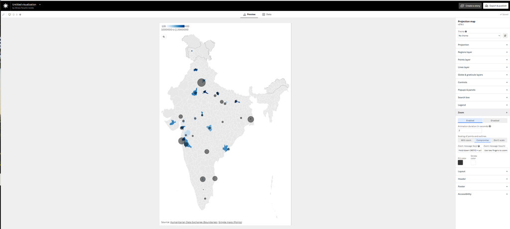

Por lo tanto, vamos a usar otro tipo de gráfico, por ejemplo, un gráfico de **barras apiladas** nos mostrará a simple vista si hay alguna ciudad que destaque sobre las demás. Como en el dataset anterior ya tenemos calculadas las proporciones, no necesitamos hacer nada más, usaremos ese csv.

## Conclusiones

Como podemos ver a lo largo de las diferentes visualizaciones que tenemos en la *storytelling* https://public.flourish.studio/story/2816670/, hemos conseguido responder a todas las preguntas que nos habíamos planteado:

Por lo tanto, hemos conseguido nuestros objetivos, a falta de haber tenido datos de más ciudades de la India para poder responder a la pregunta *Hay alguna ciudad con más tendencia al suicidio?* con un mapa, que siempre queda más atractivo y capta más la atención.